# Projection for Total Expenditures

January 30, 2019

# Five year projections

Based on the first model in the expenditure analysis memo (using all 99 ARL universities), I generated 5-year budget projections. The inputs – number of faculty, undergraduates, graduate students, phd fields, and grants/endowment monies were each projected to grow at yearly rates consistent with UVA’s overall projections (faculty and graduate students at 3.5%, undergraduate students at 3%, research grants at 4%, and the number of phd fields at 1%, to generate an increase of 2 over the five year period).

The graph below presents the predicted expenditures over 5 years based on the model (model) compared to expenditures based on 2% growth per year.

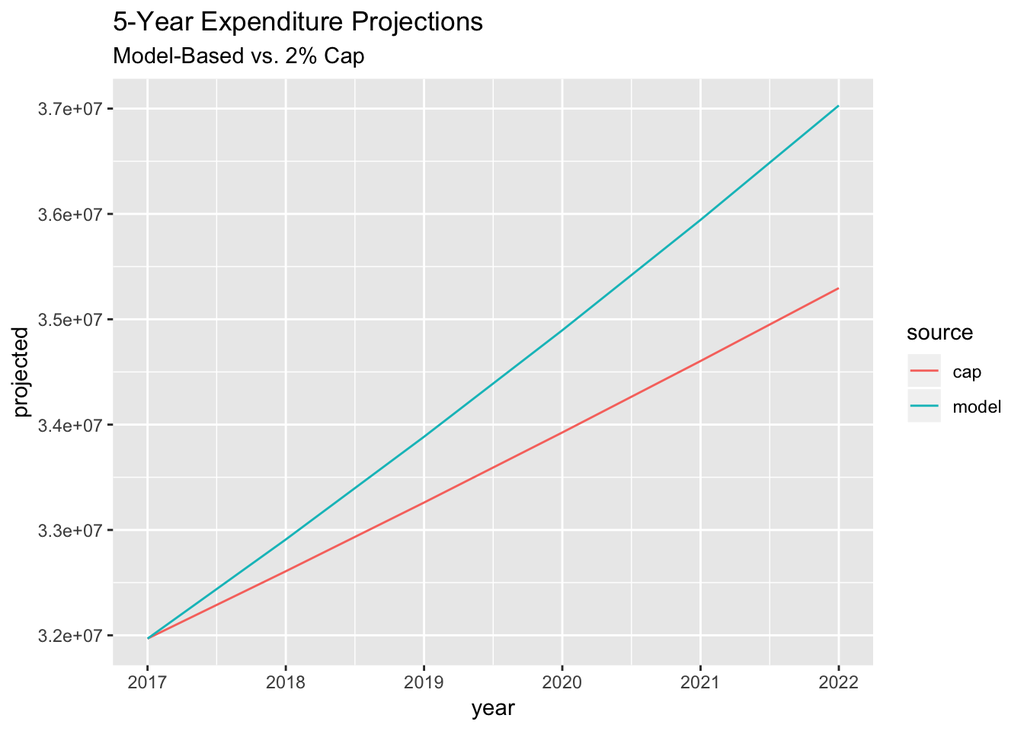

The model-based prediction generates a faster rate of increase than that produced by steady 2% growth. But these predictions are probabilistic and uncertain. Adding confidence intervals to the model projections makes clear that the 2% growth budget is well within the model’s uncertainty estimation.

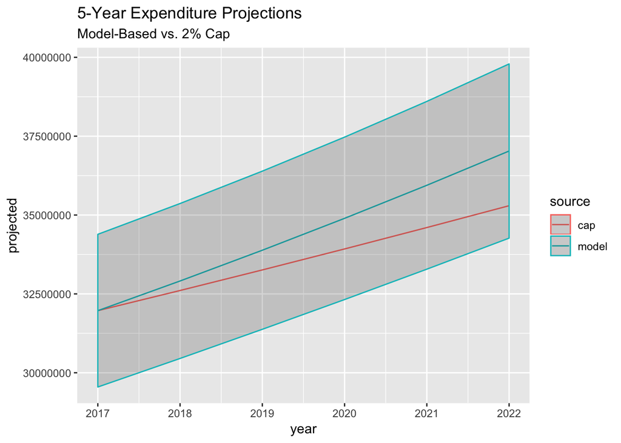

Again, these are confidence intervals, not prediction interals which are both more appropriate and much wider still.